# Parallel Execution

GPUs are notoriously good at parallel execution. For us, we can take advantage of this by parallellizing the reservoir simulation. This isn't obvious, so let's check it out. We can validate on the test set (or train on the training set!) $n-$ times as fast if we break it into $n$ pieces. From the last notebook, we can plot our performance on NARMA10:

```
0.5887707279682656
```

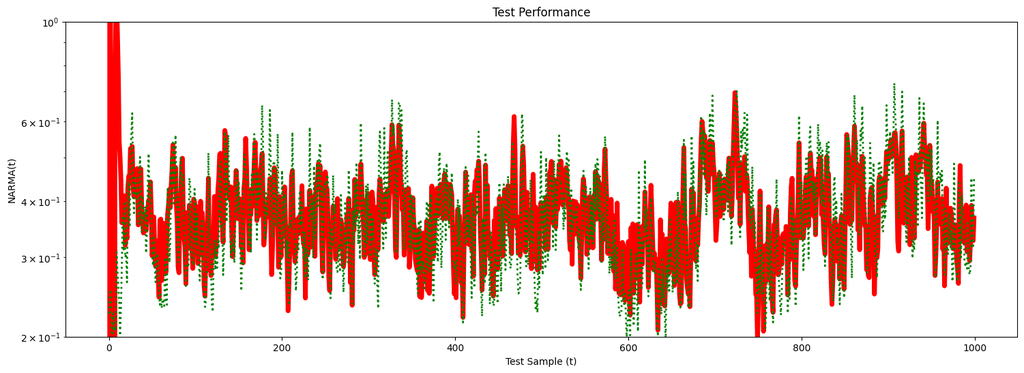

```python
from reservoir import plot_NARMA
Wout, Echo, Y_test, data_test = plot_NARMA()
```

# Speeding up simulation

Now, we'll plot the testing data for the same trained reservoir, but split into two batches.

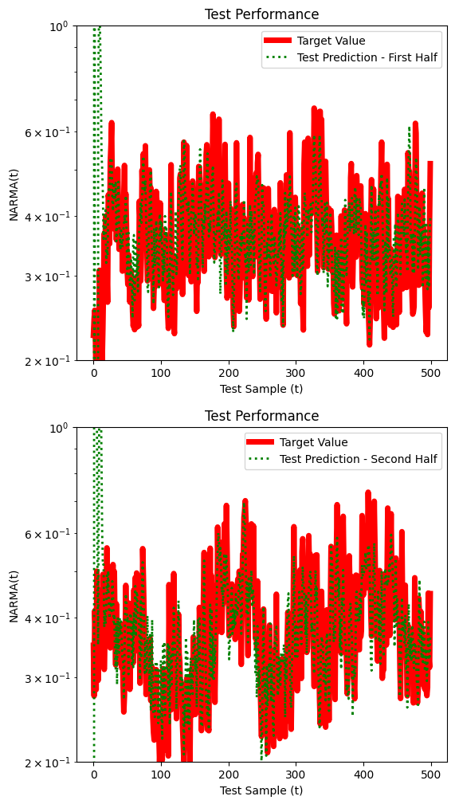

```python
import matplotlib.pyplot as plt
from reservoir import reservoir_slow, fetchData
import numpy as np

np.random.seed(137)
plt.figure(figsize=(6, 12))

index = len(data_test) // 2
RA_Test1 = reservoir_slow(data_test[:index], *Echo, True)
RA_Test2 = reservoir_slow(data_test[index:], *Echo, True)

# Plot for first half of data
plt.subplot(2, 1, 1)
plt.plot(Y_test[:index], color='red',  linewidth=5, label='Target Value')
plt.plot(np.dot(RA_Test1, Wout), color='green', linestyle=":",  linewidth=2,
         label='Test Prediction - First Half')
plt.legend()
plt.ylabel("NARMA(t)")
plt.xlabel("Test Sample (t)")
plt.title("Test Performance")
plt.yscale('log')
plt.ylim(.2,1)

# Plot for second half of data
plt.subplot(2, 1, 2)
plt.plot(Y_test[index:], color='red',  linewidth=5, label='Target Value')
plt.plot(np.dot(RA_Test2, Wout), color='green', linestyle=":",  linewidth=2,
         label='Test Prediction - Second Half')
plt.legend()
plt.ylabel("NARMA(t)")
plt.xlabel("Test Sample (t)")
plt.title("Test Performance")
plt.yscale('log')
plt.ylim(.2,1)
plt.show()
```

The green spikes in the beginning need to be thrown away, but now these are embarassingly parallel matrix multiplications. Let's see if we can get a speed up by taking advantage of this.

```python
import torch
from functools import reduce
from itertools import combinations

def reservoir(data, Win, Wres, inSize, resSize, alpha, batch_number, power_set):
    # Apple "metal performance shaders".
    device = torch.device("mps")

    # Convert Wres, Win, and data to tensor and assign device
    Wres = torch.tensor(Wres, device=device, dtype=torch.float32)
    Win = torch.tensor(Win, device=device, dtype=torch.float32)
    data = torch.tensor(data, device=device, dtype=torch.float32)

    batch_size = len(data) // batch_number
    # We'll trim some of the data for simplicity, we can fix this later.
    data = data[:batch_number*batch_size]
    new_data = data.view(batch_number, batch_size)

    # Replicate Wres, Win for batch_number times
    Wres_copies = Wres.repeat(batch_number, 1, 1)
    Win_copies = Win.repeat(batch_number, 1, 1)

    R_copies = 0.1 * (torch.ones((batch_number, resSize), device=device) - 0.5)
    dm = torch.zeros((batch_number, batch_size - 50, 1 + inSize + resSize), device=device)

    for t in range(batch_size):
        u = new_data[:, t, None]
        ones = torch.hstack((torch.ones(u.shape[0], 1, device=device), u))
        R_copies = (1 - alpha)*R_copies +\
        alpha*torch.tanh(torch.einsum('ij,ijk->ik', ones, Win_copies) +\
                  torch.einsum('ij,ijk->ik', R_copies, Wres_copies))
        if t >= 50:
            dm[:, t-50, :] = torch.cat((ones, R_copies), dim=1)
    dm = dm.view(-1, 1+inSize+resSize)
    new_data = new_data[:, 50:].flatten()
    s = list(dm.T)[2:]
    chosen_subsets = []

    if power_set:
        # Generate all subsets
        ones = torch.ones(new_data.shape[0], dtype=torch.float32)
        for subset_size in range(len(s)+1):
            for subset in combinations(s, subset_size):
                chosen_subsets.append([l.cpu().numpy() for l in subset])
        power_signals = [reduce(lambda a, b: a*b, el, ones.numpy()) for el in chosen_subsets]
        power_signals = [torch.tensor(pw, dtype=torch.float32)
                         for i, pw in enumerate(power_signals)]
        power_signals = [el.cpu() for el in list(dm.T)] + power_signals

    return torch.vstack(power_signals).T, new_data
```

# Seeing the speed up.

Now we are going to see if we get a speed up with this new code. In the next notebook we are going to simulate many different reservoirs to see their empirical performance as a function of size, where we also vary the amount of noise we inject into the reservoir. For this notebook, we will simply vary the amount of training data we consider to demonstrate a speedup. For small networks, this amount of training data is unnecessary, and harmful due to overfitting - we are just benchmarking the code!

```python
from reservoir import ESN_init, fetchData, reservoir_slow
import numpy as np

powerset = True
inSize = outSize = 1
resSize = 5
alpha = .7
sparsity = .9
train_cycles = 1000000
Echo = ESN_init(inSize, outSize, resSize, alpha, sparsity)
data_train, Y_train = fetchData(train_cycles)
```

In the next cell, we vary over the number of batches. Parallelizing the computation with more batches is good, but the more batches we use, the more data we have to throw away.

```python
from time import time
number_of_batches = [20000, 10000, 2000, 1000]
runtimes = []
for batch_number in number_of_batches:
    start = time()
    reservoir(data_train, *Echo, batch_number, powerset)
    stop = time()
    runtimes.append(stop-start)
print(runtimes)
```

```
[0.7789459228515625, 0.9311521053314209, 1.4612369537353516, 2.1751229763031006]
```

Because we need to throw away the initial samples while the reservoir "warms-up", we lose data each run (50 per batch). We'll benchmark the slow reservoir for each of these reduced training data lengths.

```python
from time import time
number_of_batches = [20000, 10000, 2000, 1000]
runtimesserial = []
for batch_number in number_of_batches:
    start = time()
    reservoir_slow(data_train[:-50*batch_number], *Echo, powerset)
    stop = time()
    runtimesserial.append(stop-start)
print(runtimesserial)
```

```
[0.00034689903259277344, 9.030734062194824, 16.001220226287842, 16.72932481765747]
```

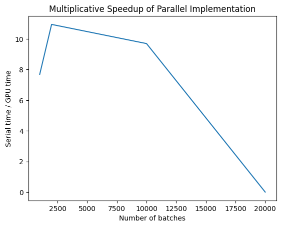

```python
speedups = np.array(runtimesserial)/np.array(runtimes)
plt.plot(number_of_batches, speedups)
plt.title("Multiplicative Speedup of Parallel Implementation")
plt.xlabel("Number of batches")
plt.ylabel("Serial time / GPU time");
```

```python
print(f"The maximum speed up is {np.max(speedups)}!")
```

```
The maximum speed up is 10.950462336299404!
```

Even with this simple optimization, just including a batch index, we see that we decrease training time. We would expect that $50*$numbatches is significantly smaller than the amount of training data, the cost of throwing away data is neglible, and we are turning a serial task into a parallel task. We expect to get a speedup from this as long as the size of the parallelized computations we make is no larger than the GPU size. A better benchmark might be to fix the goal (which is the amount of non-thrown away training data).

```python
from time import time
from reservoir import ESN_init, fetchData, reservoir_slow
import numpy as np

train_cycles = 100000
number_of_batches = [500, 1000, 1500, 2000, 2500, 3000, 3500, 4000, 4500, 5000]
runtimes = []
for batch_number in number_of_batches:
    Echo = ESN_init(inSize, outSize, resSize, alpha, sparsity)
    data_train, Y_train = fetchData(batch_number * 50 + train_cycles)
    start = time()
    reservoir(data_train, *Echo, batch_number, powerset)
    stop = time()
    runtimes.append(stop-start)
print(runtimes)
```

```
[0.38776707649230957, 0.2525200843811035, 0.24639606475830078, 0.17734909057617188, 0.1612389087677002, 0.15805602073669434, 0.1435999870300293, 0.1475820541381836, 0.1337909698486328, 0.14001893997192383]
```

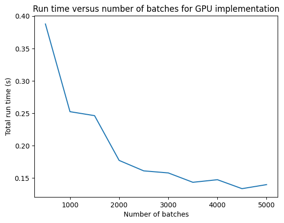

```python
plt.plot(number_of_batches, runtimes)
plt.xlabel("Number of batches")
plt.ylabel("Total run time (s)")
plt.title("Run time versus number of batches for GPU implementation");
```

We can compare this to the serial implementation time.

```python
from time import time
Echo = ESN_init(inSize, outSize, resSize, alpha, sparsity)
data_train, Y_train = fetchData(train_cycles)
start = time()
reservoir_slow(data_train, *Echo, powerset)
stop = time()
runtimesserial = stop - start
print(runtimesserial)
```

```
1.8172321319580078
```

And so we can plot the speedup again, this time we remember we fixed the desired training data post-throwing away the warmup data. It's similar --- no surprises here.

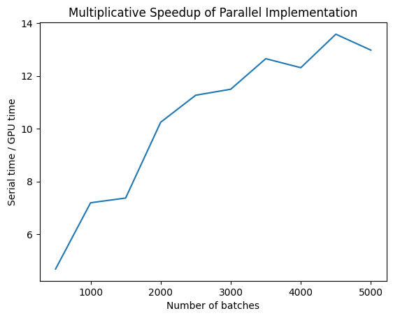

```python
plt.plot(number_of_batches, runtimesserial/np.array(runtimes))
plt.title("Multiplicative Speedup of Parallel Implementation")
plt.xlabel("Number of batches")
plt.ylabel("Serial time / GPU time");
```

In addition to the overhead from throwing away data, there is a maximum imposed by the size of the M1 chip. It seems as if we have hit one of these, but we still outperform the serial implementation for all batch sizes. Now we're ready to use this simulator in the next notebook to see if we can observe any empiral scaling behavior for these networks in the presence of noise!